# Adatvizualizáció I.

## Base R

Most pedig készítsünk pár plotot az előbb létrehozott metszetekre.

### Pont- és vonaldiagram

Pont- és vonaldiagramot a `plot(x,y,...)` paranccsal lehet előállítani. A lehetséges függvényparaméterek (*x*, *y* és a *‘…’*-tal jelölt további paraméterek) leírását a `?plot` parancs futtatásával kaphatjátok meg.

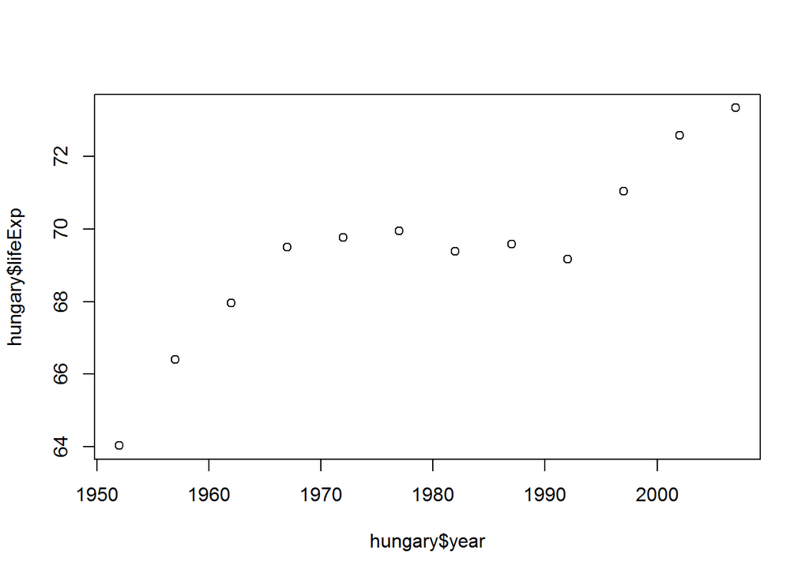

```r
# egyszerű scatter plot
plot(hungary$year, hungary$lifeExp)
```

Ha nem adunk meg további paramétereket, akkor az ábra nem kap címet, a tengelyfeliratok pedig a megadott változók nevei lesznek. A feliratok beállítását a `main`, `xlab` és `ylab` paraméterekkel tehetjük meg.

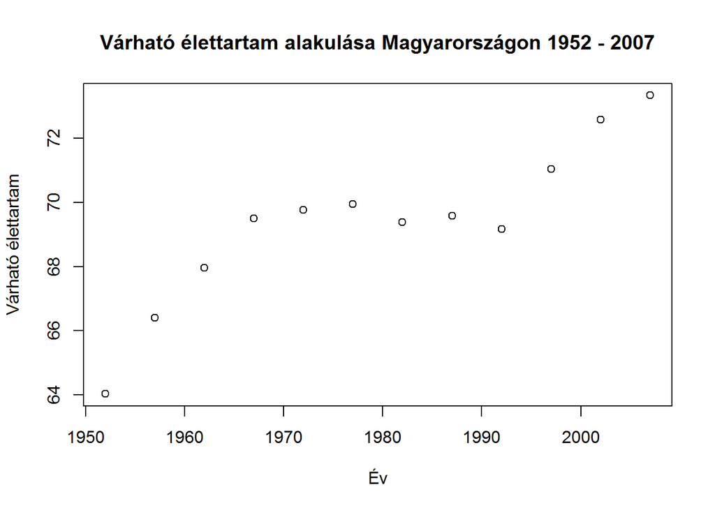

```r
# cím és tengelyfeliratok hozzáadása
plot(hungary$year, hungary$lifeExp
     ,main = "Várható élettartam alakulása Magyarországon 1952 - 2007"
     ,xlab = "Év"
     ,ylab = "Várható élettartam")
```

A plothoz hozzáadhatóak egyenesek az `abline()` paranccsal, például a két változó kapcsolatát leíró regressziós egyenes.

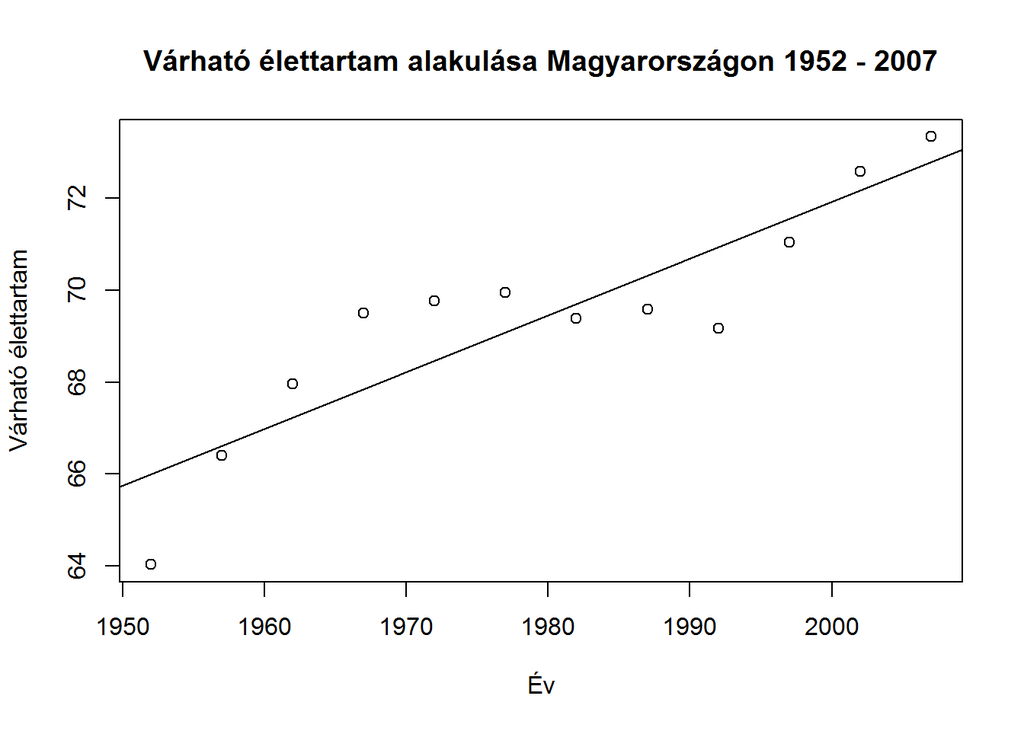

```r
# Az előző plot parancsot követően közvetlenül futtajuk az abline parancsot
plot(hungary$year, hungary$lifeExp
     ,main = "Várható élettartam alakulása Magyarországon 1952 - 2007"
     ,xlab = "Év"
     ,ylab = "Várható élettartam")
abline(lm(hungary$lifeExp ~ hungary$year))
```

### Egyéb diagram típusok

Hisztogram a `hist()`, boxplot a `boxplot()`, oszlopdiagram a `barplot()`, kördiagram a `pie()` paranccsal állítható elő.

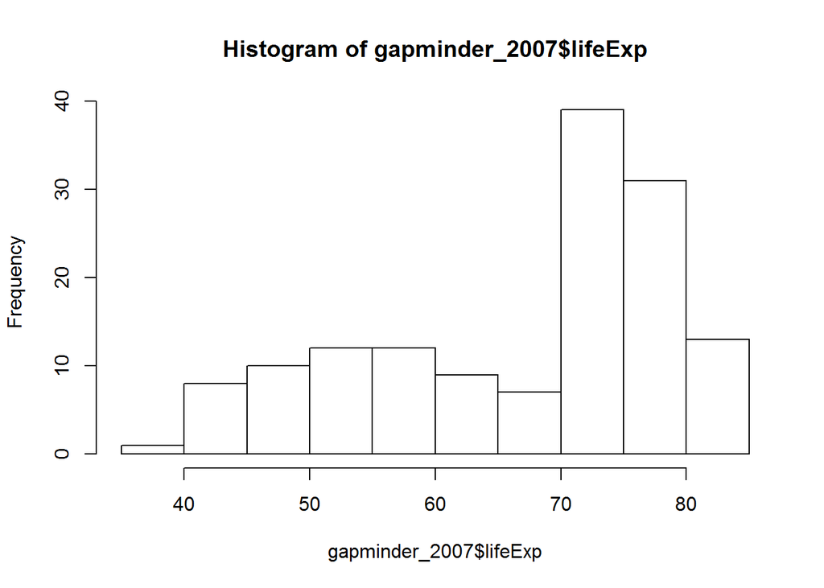

```r
# 2007-es országonkénti várható élettartam megoszlása
hist(gapminder_2007$lifeExp)
```

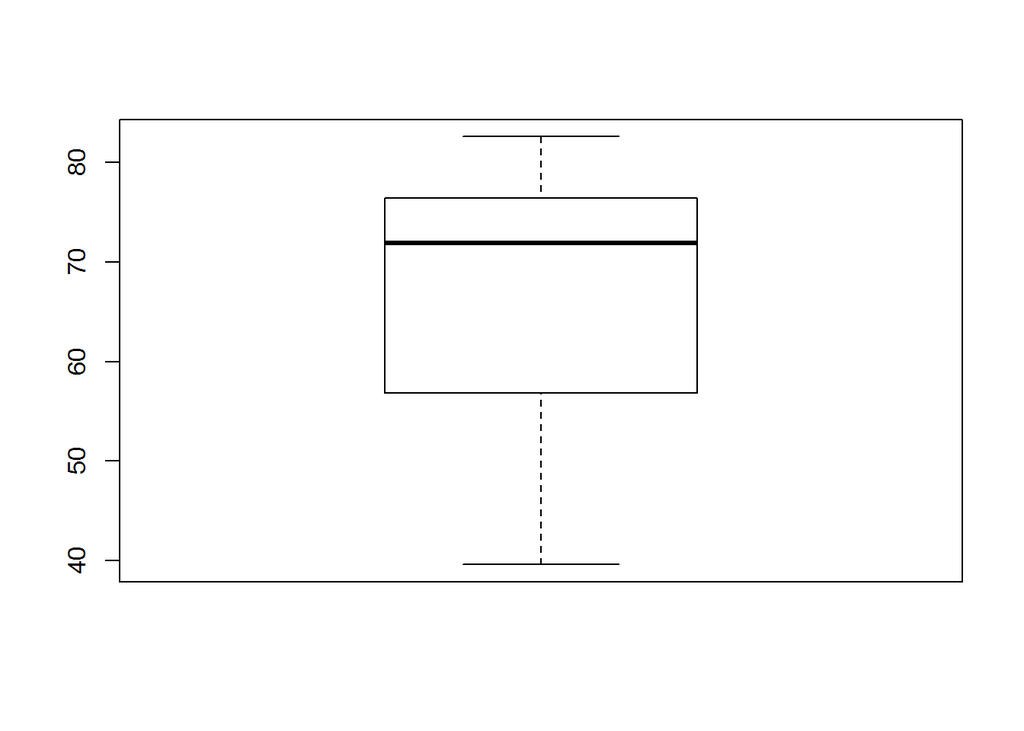

```r
# Boxplot a 2007-es országonkénti várható élettartamra
boxplot(gapminder_2007$lifeExp)
```

## ggplot2

### Alap syntax

A csomag telepítéséhez futtassuk a következő parancsot: `install.packages("ggplot2", repos = "http://cran.rapporter.net/")`

ggplot ábrák készítésekor először megadjuk a `ggplot()` függvényben, hogy milyen data.frame alapján szeretnénk az ábrát elkészíteni, illetve, hogy a data.frame-ben található változók milyen szerepet fognak betölteni az ábrán (x, y, méret, csoport jelölő … stb.), majd meghatározzuk a megjelenítési módot, vagyis, hogy az adatokat hogyan transzformáljuk vizuális elemekké. Ilyen megjelenítési mód például a pontdiagram, ahol a az (x,y) adatpárok a pontok koordinátáit jelölik, vagy oszlopdiagram, ahol az x változó a kategóriákat adja meg, az y pedig az oszlopok magasságát. A megjelenítési módokat layereknek, vagyis rétegeknek nevezzük, ezekből egy vagy akár több is hozzáadható az ábrához, ahogy ezt hamarosan látni fogjuk.

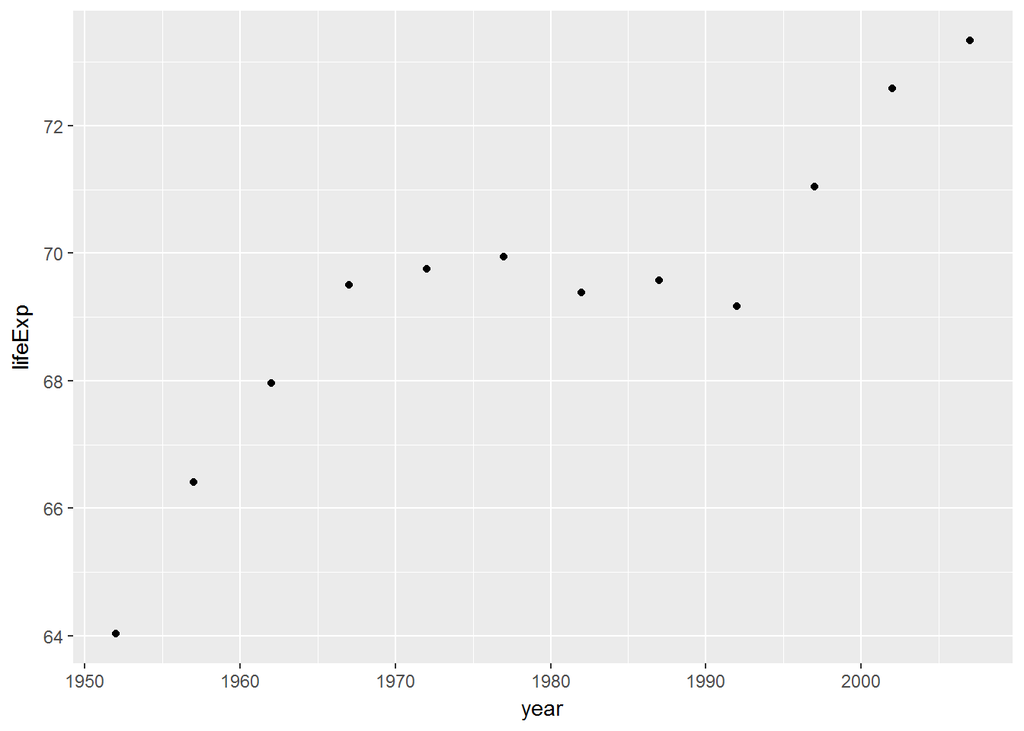

```r
library(ggplot2)

# Pontdiagram: Várható élettartam alakulása Magyarországon
ggplot(data = hungary) + # data set megadása
  geom_point(mapping = aes(x = year, y = lifeExp)) # mapping és megjelenítési mód megadása
```

Egy-egy ábra készítése során elég egyszer megadnunk, hogy milyen data.frame-t használunk, attől kezdve elég a változók neveit megadnunk, nem kell visszautalni a data set nevére *$* jelöléssel vagy más syntax-szal. A scriptben látott *+* jelölés a *%>%* (pipe) operátorhoz hasonlóan tovább csatornázza az outputot az egyes parancsok között. A megjelenítési módhoz használt függvények *geom + típus* elnevezési konvenciót követnek (pl. `geom_point()`). Amikor a megjelenítési módot határozzuk meg, az összes olyan jellemző, ami függ valamelyik változótól, az `aes()` (**aes**thetic) függvényben kap helyet, a többi paraméter pedig azon kívül vesszővel elválasztva.

Ha a pontokat egyszerűen szeretnénk átszínezni és felnagyítani a változók értékétől függetlenül:

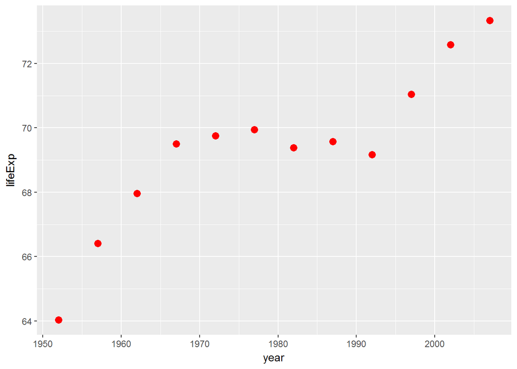

```r
# Pontdiagram: Várható élettartam alakulása Magyarországon
ggplot(data = hungary) +
  # a color és a size paraméter az aes()-en KÍVÜL szerepel
  geom_point(mapping = aes(x = year, y = lifeExp), color = "red", size=3)
```

Ha a pontok színét az évszámtól szeretnénk függővé tenni, akkor a következő syntaxot használhatjuk:

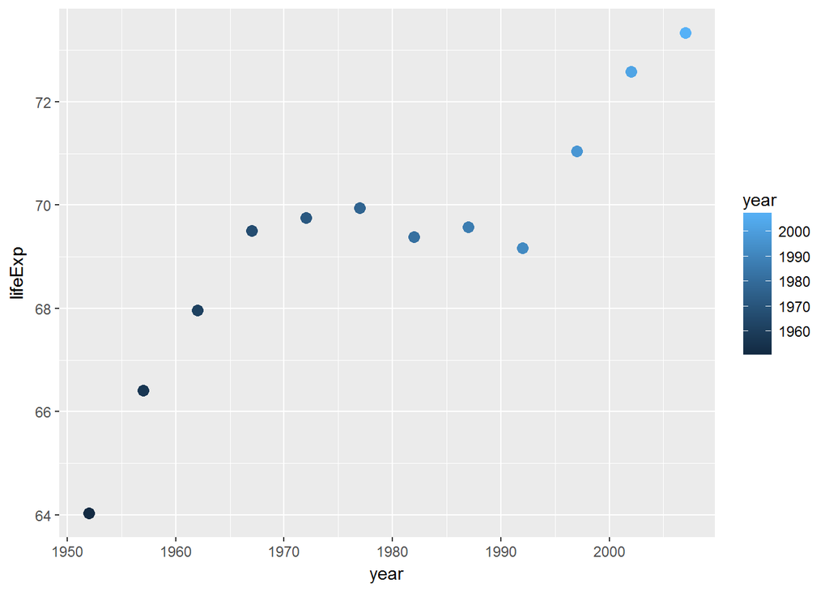

```r
# Pontdiagram: Várható élettartam alakulása Magyarországon
ggplot(data = hungary) +
  # a color paraméter az aes()-en BELÜL szerepel
  geom_point(mapping = aes(x = year, y = lifeExp, color = year), size=3)
```

Ha az egyes paraméterek értékét egy változótól tesszük függővé, ahogy azt a `color = year` beállításnál láttuk, akkor az elért hatás függ a változó típusától. Szín megadásánál, ha a változó folytonos, mint például az év változó, akkor a függvény folytonos színskálát rendel az értékekhez, ha faktor, akkor kategoriális színskálát, ami segít az egyes kategóriák megkülönböztetésében. A következő példában az évet transzformáljuk faktorrá, és úgy tegyük tegyük tőle függővé a színezést.

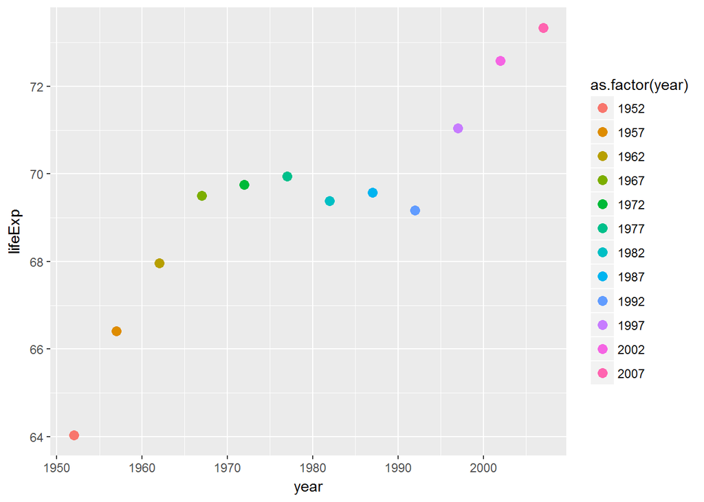

```r
# Pontdiagram: Várható élettartam alakulása Magyarországon
ggplot(data = hungary) +
  # a color paraméter az aes()-en BELÜL szerepel; az év faktor
  geom_point(mapping = aes(x = year, y = lifeExp, color = as.factor(year)), size=3)
```

A színen kívül számos más paraméter is állítható a megjelenítésben, például a méret (size), jelölő formája (shape), kitöltési szín (fill), vagy az áttetszőség mértéke (alpha). Az állítható paraméterek listája megtalálható az egyes diagram típusok dokumentációjában, lásd például `?geom_point`.

Az állítható paraméterek, úgymint a szín, a méret, vagy az eltérő jelölő formák segítenek abban, hogy a charton több információt jelenítsünk meg, vagy felhívjuk a figyelmet a chart fő mondanivalójára. Ha például az országokat külön adatpontokként szeretnénk megjeleníteni a várható élettartam - GDP/fő pontdiagrammon, akkor jelölhetjük az eltérő kontinenshez tartozó országokat különböző színnel, hogy a kontinensek továbbra is összehasonlíthatóak legyenek.

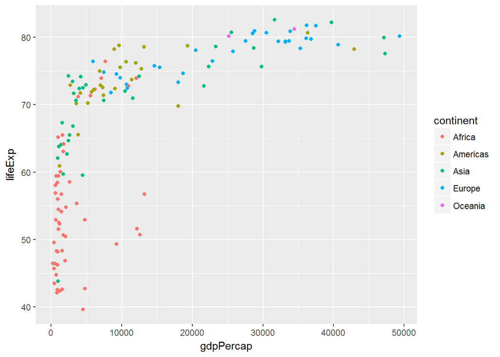

```r
# Pontdiagram: várható élettartam az egy főre eső GDP függvényében (2007)
ggplot(data = gapminder_2007) +
  # a color paraméter az aes()-en BELÜL szerepel
  geom_point(mapping = aes(x = gdpPercap, y = lifeExp, color = continent))
```